# Pre-Processing

Load the data

```python
import pandas as pd
df = pd.read_csv("traffic_violations_raw.csv")
```

Main stats

Shape

```python
print("Dataset shape:", df.shape)
```

```
Dataset shape: (2014196, 43)
```

Preview

```python
df.head()
```

|  | SeqID | Date Of Stop | Time Of Stop | Agency | SubAgency | Description | Location | Latitude | Longitude | Accident | ... | Charge | Article | Contributed To Accident | Race | Gender | Driver City | Driver State | DL State | Arrest Type | Geolocation |
| --- | --- | --- | --- | --- | --- | --- | --- | --- | --- | --- | --- | --- | --- | --- | --- | --- | --- | --- | --- | --- | --- |
| 0 | 93734695-93e6-4c69-bcf2-d0d9ee47286a | 10/24/2024 | 13:30:00 | MCP | 3rd District, Silver Spring | EXCEEDING POSTED MAXIMUM SPEED LIMIT: 60 MPH I... | NEW HAMPSHIRE AVE / VALLEY BROOK | 39.058970 | -76.997734 | No | ... | 21-801.1 | Transportation Article | False | BLACK | M | GAITHERSBURG | MD | MD | A - Marked Patrol | (39.0589701666667, -76.997734) |
| 1 | 20b92176-702a-4071-85e5-43ac0c994529 | 10/24/2024 | 04:35:00 | MCP | 4th District, Wheaton | DRIVER FAILURE TO STOP AT STEADY CIRCULAR RED ... | RANDOLPH RD @ JUDSON RD | 39.058199 | -77.054977 | No | ... | 21-202(h1) | Transportation Article | False | HISPANIC | F | SILVER SPRING | MD | MD | A - Marked Patrol | (39.058199, -77.0549773333333) |
| 2 | fdf2e5b6-bd2c-4bfc-be33-2ae32e82657c | 10/24/2024 | 08:23:00 | MCP | 2nd District, Bethesda | DRIVER FAILURE TO STOP FOR PEDESTRIAN IN CROSS... | BRADLEY/ FAIRFAX | 38.977576 | -77.100526 | No | ... | 21-502(a2) | Transportation Article | False | WHITE | F | WASHINGTON | DC | DC | A - Marked Patrol | (38.9775758333333, -77.1005258333333) |
| 3 | 42de2c93-f9b4-4154-b5d0-20106e849909 | 10/23/2024 | 22:27:00 | MCP | 3rd District, Silver Spring | DRIVING MOTOR VEHICLE ON HIGHWAY WITHOUT REQUI... | GEORGIA AVE/WAYNE AVE | 38.993102 | -77.026927 | No | ... | 16-101(a1) | Transportation Article | False | HISPANIC | M | WASHINGTON | DC | MD | A - Marked Patrol | (38.9931023333333, -77.0269273333333) |
| 4 | f2dc85fa-311f-444c-af79-e1696e495190 | 10/24/2024 | 21:13:00 | MCP | 3rd District, Silver Spring | DRIVING VEH. W/O ADEQUATE REAR REG. PLATE ILLU... | GEORGIA AVE/13TH ST | 39.069426 | -77.162020 | No | ... | 22-204(f) | Transportation Article | False | BLACK | M | WASHINGTON | DC | DC | A - Marked Patrol | (39.0694258333333, -77.1620203333333) |

5 rows × 43 columns

General summary

```python
df.describe(include='all')
```

|  | SeqID | Date Of Stop | Time Of Stop | Agency | SubAgency | Description | Location | Latitude | Longitude | Accident | ... | Charge | Article | Contributed To Accident | Race | Gender | Driver City | Driver State | DL State | Arrest Type | Geolocation |
| --- | --- | --- | --- | --- | --- | --- | --- | --- | --- | --- | --- | --- | --- | --- | --- | --- | --- | --- | --- | --- | --- |
| count | 2014196 | 2014196 | 2014196 | 2014196 | 2014196 | 2014186 | 2014192 | 2.014196e+06 | 2.014196e+06 | 2014196 | ... | 2014196 | 1923588 | 2014196 | 2014196 | 2014196 | 2013679 | 2014185 | 2013267 | 2014196 | 2014196 |
| unique | 1143264 | 4900 | 1440 | 1 | 9 | 17351 | 263287 | NaN | NaN | 2 | ... | 1183 | 6 | 2 | 6 | 3 | 9226 | 68 | 72 | 19 | 997198 |
| top | 33c49de3-9e36-4f36-9326-b59a95e86fe8 | 03/17/2015 | 23:30:00 | MCP | 4th District, Wheaton | DRIVER FAILURE TO OBEY PROPERLY PLACED TRAFFIC... | MONTGOMERY VILLAGE AVE @ RUSSELL AVE | NaN | NaN | No | ... | 21-801.1 | Transportation Article | False | WHITE | M | SILVER SPRING | MD | MD | A - Marked Patrol | (0.0, 0.0) |
| freq | 59 | 1281 | 2947 | 2014196 | 444601 | 166785 | 2366 | NaN | NaN | 1958878 | ... | 276440 | 1904247 | 1958878 | 675951 | 1356831 | 490605 | 1820494 | 1755508 | 1619112 | 148321 |
| mean | NaN | NaN | NaN | NaN | NaN | NaN | NaN | 3.620662e+01 | -7.143721e+01 | NaN | ... | NaN | NaN | NaN | NaN | NaN | NaN | NaN | NaN | NaN | NaN |
| std | NaN | NaN | NaN | NaN | NaN | NaN | NaN | 1.020878e+01 | 2.014248e+01 | NaN | ... | NaN | NaN | NaN | NaN | NaN | NaN | NaN | NaN | NaN | NaN |
| min | NaN | NaN | NaN | NaN | NaN | NaN | NaN | 0.000000e+00 | -1.512560e+02 | NaN | ... | NaN | NaN | NaN | NaN | NaN | NaN | NaN | NaN | NaN | NaN |
| 25% | NaN | NaN | NaN | NaN | NaN | NaN | NaN | 3.901656e+01 | -7.719252e+01 | NaN | ... | NaN | NaN | NaN | NaN | NaN | NaN | NaN | NaN | NaN | NaN |
| 50% | NaN | NaN | NaN | NaN | NaN | NaN | NaN | 3.906600e+01 | -7.708704e+01 | NaN | ... | NaN | NaN | NaN | NaN | NaN | NaN | NaN | NaN | NaN | NaN |
| 75% | NaN | NaN | NaN | NaN | NaN | NaN | NaN | 3.913553e+01 | -7.702694e+01 | NaN | ... | NaN | NaN | NaN | NaN | NaN | NaN | NaN | NaN | NaN | NaN |
| max | NaN | NaN | NaN | NaN | NaN | NaN | NaN | 4.154316e+01 | 3.906444e+01 | NaN | ... | NaN | NaN | NaN | NaN | NaN | NaN | NaN | NaN | NaN | NaN |

11 rows × 43 columns

Missing Values

```python
print("Missing values per column:")
print(df.isnull().sum())
```

```
Missing values per column:
SeqID                            0
Date Of Stop                     0
Time Of Stop                     0
Agency                           0
SubAgency                        0
Description                     10
Location                         4
Latitude                         0
Longitude                        0
Accident                         0
Belts                            0
Personal Injury                  0
Property Damage                  0
Fatal                            0
Commercial License               0
HAZMAT                           0
Commercial Vehicle               0
Alcohol                          0
Work Zone                        0
Search Conducted            765508
Search Disposition         1925789
Search Outcome              784799
Search Reason              1925789
Search Reason For Stop      765811
Search Type                1925797
Search Arrest Reason       1953195
State                           59
VehicleType                      0
Year                         10555
Make                            73
Model                          221
Color                        22095
Violation Type                   0
Charge                           0
Article                      90608
Contributed To Accident          0
Race                             0
Gender                           0
Driver City                    517
Driver State                    11
DL State                       929
Arrest Type                      0
Geolocation                      0
dtype: int64
```

Drop SeqID

```python
if "SeqID" in df.columns:
    df.drop(columns=["SeqID"], inplace=True)
```

Convert 'Date Of Stop' to 'Weekday'

```python
df["Date Of Stop"] = pd.to_datetime(df["Date Of Stop"], errors="coerce")
df["Weekday"] = df["Date Of Stop"].dt.weekday  # Monday=0, Sunday=6
```

Convert 'Time Of Stop' to 'Hour'

```python
df["Time Of Stop"] = pd.to_datetime(df["Time Of Stop"], format="%H:%M:%S", errors="coerce")
df["Hour"] = df["Time Of Stop"].dt.hour
```

Drop original datetime columns

```python
df.drop(columns=["Date Of Stop", "Time Of Stop"], inplace=True)
```

Preview updated DataFrame

```python
print(df[["Weekday", "Hour"]].head())
```

```
   Weekday  Hour
0        3    13
1        3     4
2        3     8
3        2    22
4        3    21
```

Drop irrelevant or redundant columns

```python
columns_to_drop = ["Agency", "SubAgency", "Description", "Location","Geolocation"]
df.drop(columns=columns_to_drop, inplace=True)
```

List of binary columns

```python
binary_cols = [
    "Accident", "Belts", "Personal Injury", "Property Damage", "Fatal",
    "Commercial License", "HAZMAT", "Commercial Vehicle", "Alcohol", "Work Zone"
]

df[binary_cols] = df[binary_cols].replace({"Yes": 'TRUE', "No": 'FALSE'})
```

Extract the code of reason to stop

```python
import pandas as pd

df['Search Reason For Stop'] = df['Search Reason For Stop'].str.extract(r'(\d{2})')
df['Charge'] = df['Charge'].str.extract(r'(\d{2})')
```

Fill blanks in all search-related fields with "NotApplicable"

```python
search_cols = [
    "Search Conducted",
    "Search Disposition",
    "Search Outcome",
    "Search Reason For Stop",
    "Search Reason",
    "Search Type",
    "Search Arrest Reason"
]

for col in search_cols:
    df[col] = df[col].fillna("NotApplicable")
```

Drop Rows Where Latitude or Longitude = 0

```python
df = df[(df['Latitude'] != 0) & (df['Longitude'] != 0)]
```

Drop rows with empty or missing 'Violation Type'

```python
df = df[df["Violation Type"].notna() & (df["Violation Type"] != "")]
```

Drop rows with empty or missing 'color'

```python
df = df[df["Color"].notna() & (df["Color"] != "")]
```

```python
df = df.head(20200)
```

Remove numeric prefixes and keep just the descriptive label

```python
df['VehicleType'] = df['VehicleType'].str.replace(r'^\d+\s*-\s*', '', regex=True).str.strip()
```

String-based columns that may have inconsistencies

```python
string_cols = [
    "Search Conducted", "Search Disposition", "Search Outcome",
    "Search Reason", "Search Reason For Stop", "Search Type",
    "Search Arrest Reason", "State", "VehicleType", "Make",
    "Model", "Color", "Charge", "Article", "Race", "Gender",
    "Driver City", "Driver State", "DL State", "Arrest Type"
]


# Preview unique values
for col in string_cols:
    print(f"\n--- {col} ---")
    print(df[col].dropna().unique())
```

```
--- Search Conducted ---
['No' 'NotApplicable' 'Yes']

--- Search Disposition ---
['NotApplicable' 'Nothing' 'Contraband Only' 'Property Only'
 'Contraband and Property']

--- Search Outcome ---
['Citation' 'NotApplicable' 'Arrest' 'Warning' 'SERO']

--- Search Reason ---
['NotApplicable' 'Consensual' 'Probable Cause' 'Incident to Arrest' 'K-9'
 'Other']

--- Search Reason For Stop ---
['21' 'NotApplicable' '16' '22' '13' '55' '56' '11' '61' '64' '65' '23'
 '17' '53' '20' '24' '50' '25' '14' '88' '59' '89']

--- Search Type ---
['NotApplicable' 'Property' 'Both' 'Person']

--- Search Arrest Reason ---
['NotApplicable' 'Other' 'Stop' 'Warrant' 'Search' 'Traffic']

--- State ---
['MD' 'DC' 'VA' 'XX' 'IN' 'DE' 'NC' 'NY' 'WV' 'NV' 'PA' 'IL' 'NJ' 'CA'
 'TN' 'US' 'FL' 'TX' 'AR' 'MA' 'GA' 'SD' 'WY' 'UT' 'ON' 'OR' 'MO' 'LA'
 'MS' 'SC' 'WA' 'ME' 'OH' 'AZ' 'KY' 'VT' 'NH' 'NM' 'MI' 'KS' 'AL' 'OK'
 'RI' 'AK' 'CT' 'WI' 'ND' 'IA' 'ID' 'MN' 'CO']

--- VehicleType ---
['Automobile' 'Heavy Duty Truck' 'Motorcycle' 'Light Duty Truck' 'Other'
 'Station Wagon' 'Truck/Road Tractor' 'Recreational Vehicle' 'School Bus'
 'Moped' 'Utility Trailer' 'Unknown' 'Commercial Rig' 'Transit Bus'
 'Police(Non-Emerg)']

--- Make ---
['HOND' 'CHEVROLET' 'NISSAN' 'HONDA' 'LINCOLN' 'MAZD' 'VOLVO' 'TOYOTA'
 'TOYO' 'BMW' 'CHEVY' 'SUBARU' 'LEXS' 'FORD' 'MITS' 'DODGE' 'MOTORCYCLE'
 'FIAT' 'NISS' 'INFINI' 'HYUNDAI' 'CHRYSLER' 'RANGE ROVER' 'LINC' 'KIA'
```

[output cut: 189 more lines]

```
 'CT' 'SD' 'OR' 'WI' 'ME']

--- DL State ---
['MD' 'DC' 'ID' 'XX' 'MO' 'NC' 'NY' 'WV' 'NV' 'VA' 'TX' 'PA' 'ME' 'WA'
 'MS' 'IL' 'MA' 'CA' 'TN' 'FL' 'CT' 'GA' 'IT' 'NJ' 'KS' 'ON' 'LA' 'NE'
 'UT' 'DE' 'IA' 'MN' 'SC' 'NM' 'OH' 'IN' 'KY' 'VT' 'NH' 'HI' 'PE' 'MT'
 'ND' 'MI' 'AZ' 'CO' 'AL' 'WY' 'SD' 'OR' 'US' 'MB' 'WI']

--- Arrest Type ---
['A - Marked Patrol' 'B - Unmarked Patrol' 'M - Marked (Off-Duty)'
 'R - Unmarked Laser' 'Q - Marked Laser' 'E - Marked Stationary Radar'
 'L - Motorcycle' 'G - Marked Moving Radar (Stationary)'
 'I - Marked Moving Radar (Moving)' 'F - Unmarked Stationary Radar'
 'H - Unmarked Moving Radar (Stationary)' 'S - License Plate Recognition'
 'P - Mounted Patrol' 'N - Unmarked (Off-Duty)' 'O - Foot Patrol']
```

Further Cleaning to a meaningful values

```python
vehicle_group_map = {
    'Automobile': 'Automobile',
    'Station Wagon': 'Automobile',
    'Light Duty Truck': 'Automobile',

    'Motorcycle': 'Motorcycle',
    'Moped': 'Motorcycle',

    'Heavy Duty Truck': 'Truck',
    'Truck/Road Tractor': 'Truck',
    'Commercial Rig': 'Truck',

    'School Bus': 'Bus',
    'Transit Bus': 'Bus',

    'Recreational Vehicle': 'Recreational',
    'Utility Trailer': 'Recreational',

    'Limousine': 'Special Use',
    'Police(Non-Emerg)': 'Special Use',

    'Other': 'Other',
    'Unknown': 'Other'
}

df['VehicleType'] = df['VehicleType'].map(vehicle_group_map)
```

Mapping of known variants to canonical brand names

```python
make_mapping = {
    'TOYOTA': ['TOYOITA 4', 'TOIYOTA', 'TOYTOA', 'TOYOA', 'TOY', 'TTOYOTA', 'TPYOTA', 'TOYT'],
    'HONDA': ['HOND', 'HINDA', 'HODNA', 'HONA'],
    'HYUNDAI': ['HYN', 'HYUN', 'HYUND', 'HYYNDAI', 'HUNDAI', 'HYUNDA', 'HYUNDI'],
    'CHEVROLET': ['CHEV', 'CHEVVY', 'CHEVROLET', 'CHEV.', 'CHEVEROLT', 'CHEVROLEY'],
    'INFINITI': ['INFINIT', 'INFINTI', 'INFI', 'INFIN', 'INFINI'],
    'MERCEDES': ['MERZ', 'MERZB', 'MERCEDEZ', 'MERCEDEZ BENZ', 'MERCEDES', 'MERCEDES-BENZ', 'MRERCEDES', 'MERC', 'MER'],
    'NISSAN': ['NISS', 'NISSA', 'NISSAM', 'ISSAN', '4DNISSAN'],
    'VOLKSWAGEN': ['VOLKSWAGON', 'VOLK', 'VOLSWAGEN', 'VW', 'VOLKS WAGON', 'VOKSWAGEN', 'VOKSWAGON'],
    'KIA': ['KIIA'],
    'LEXUS': ['LEX', 'LEXS', 'LESUX', 'LEXU', 'LEXYS', 'LEXUX'],
    'MITSUBISHI': ['MITS', 'MITSBUSHI', 'MITSUBUSHI', 'MITSUBSHI', 'MITSO', 'MITZ'],
    'RIVIAN': ['RIVIAN', 'RIVIIAN'],
    'PORSCHE': ['PORSCHE', 'POESCHE', 'PORCHE', 'PORS'],
    'BUICK': ['BUIC', 'BUICK', 'BUICFK'],
    'AUDI': ['AUDI', 'AUDU'],
    'BMW': ['BMW', 'BMW4', 'BME', 'BMX', 'BNW'],
    'DODGE': ['DODG', 'DODGE', 'DIDGE'],
    'CHRYSLER': ['CHRY', 'CHRYSLER', 'CHRYSTLER', 'CRYSLER'],
    'ACURA': ['ACUR', 'ACURA', 'ACRUA', 'ACCURA', 'ACUA', 'ACURRA'],
    'JEEP': ['JEEP']
}


make_reverse_map = {}
for canonical, variants in make_mapping.items():
    for var in variants:
        make_reverse_map[var.upper()] = canonical

# Apply the mapping
df['Make'] = df['Make'].str.upper().map(make_reverse_map)
df['Make'] = df['Make'].fillna('OTHER')
```

Drop the 'Model' column

```python
df.drop(columns=['Model'], inplace=True)
```

Drop the 'Driver City' column

```python
df.drop(columns=['Driver City'], inplace=True)
```

Drop the 'Arrest Type' column

```python
df.drop(columns=[ 'Arrest Type'], inplace=True)
```

Drop the 'Article' column

```python
df.drop(columns=[ 'Article'], inplace=True)
```

Normalize color names

```python
df['Color'] = df['Color'].replace({
    'BLUE, LIGHT': 'BLUE',
    'BLUE, DARK': 'BLUE',
    'GREEN, DK': 'GREEN',
    'GREEN, LGT': 'GREEN',
    '': 'UNKNOWN'
})
```

```python
valid_us_states = {
    'AL', 'AK', 'AZ', 'AR', 'CA', 'CO', 'CT', 'DE', 'FL',
    'GA', 'HI', 'IA', 'ID', 'IL', 'IN', 'KS', 'KY', 'LA', 'MA',
    'MD', 'ME', 'MI', 'MN', 'MO', 'MS', 'MT', 'NC', 'ND', 'NE',
    'NH', 'NJ', 'NM', 'NV', 'NY', 'OH', 'OK', 'OR', 'PA',
    'RI', 'SC', 'SD', 'TN', 'TX', 'UT', 'VA', 'VT', 'WA',
    'WI', 'WV', 'WY'
}

def clean_state(col):
    return col.apply(lambda x: x if x in valid_us_states else 'Other')

df['State'] = clean_state(df['State'])
df['Driver State'] = clean_state(df['Driver State'])
df['DL State'] = clean_state(df['DL State'])
```

Keep only realistic years (1980–2025)

```python
df = df[(df['Year'] >= 1980) & (df['Year'] <= 2025)]

df['Year'] = df['Year'].astype(int)


def categorize_year(y):
    if y >= 2015:
        return 'Recent'
    elif y >= 2005:
        return '2005-2014'
    elif y >= 1995:
        return '1995-2004'
    elif y >= 1985:
        return '1985-1994'
    else:
        return 'Old'
df['YearGroup'] = df['Year'].apply(categorize_year)
df.drop(columns='Year', inplace=True)
```

```python
def categorize_hour(h):
    if 5 <= h <= 11:
        return 'Morning'
    elif 12 <= h <= 16:
        return 'Afternoon'
    elif 17 <= h <= 20:
        return 'Evening'
    else:
        return 'Night'
df['HourGroup'] = df['Hour'].apply(categorize_hour)
df.drop(columns='Hour', inplace=True)
```

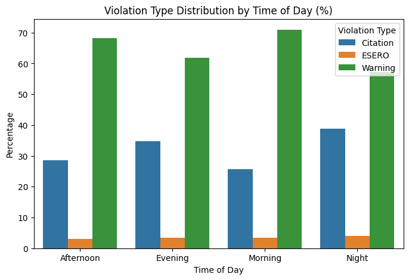

```python
# 6. Violation Type by Time of Day (as percentage)
plt.figure(figsize=(8,5))

# Calculate percentage distribution
group_counts = df.groupby(['HourGroup', 'Violation Type']).size().reset_index(name='count')
total_per_time = group_counts.groupby('HourGroup')['count'].transform('sum')
group_counts['percentage'] = 100 * group_counts['count'] / total_per_time

# Plot using seaborn barplot
sns.barplot(x='HourGroup', y='percentage', hue='Violation Type', data=group_counts)
plt.title("Violation Type Distribution by Time of Day (%)")
plt.ylabel("Percentage")
plt.xlabel("Time of Day")
plt.legend(title='Violation Type')
plt.show()
```

```python
def group_stop_reason(code):
    if code.startswith('21'):
        return 'Traffic'
    elif code.startswith('16'):
        return 'License'
    elif code.startswith('22'):
        return 'Equipment'
    elif code.startswith('13'):
        return 'Registration'
    elif code.startswith('11'):
        return 'Commercial'
    elif code.startswith('14'):
        return 'Behavior'
    elif code.startswith('17'):
        return 'Speeding'
    elif code in ['23', '24', '25', '20']:
        return 'Misc'
    elif code in ['55', '56', '59', '61', '64', '65', '88', '89']:
        return 'Other'
    else:
        return 'NotApplicable'

df['SearchReasonGroup'] = df['Search Reason For Stop'].apply(group_stop_reason)
df.drop(columns='Search Reason For Stop', inplace=True)
```

Contributed To Accident True/False

```python
df['Contributed To Accident'] = df['Contributed To Accident'].map({True: 1, False: 0})
```

```python
string_cols = [
    "Search Conducted", "Search Disposition", "Search Outcome",
    "Search Reason", "SearchReasonGroup", "Search Type",
    "Search Arrest Reason", "State", "VehicleType", "Make",
     "Color", "Charge",  "Race", "Gender"
    , "Driver State", "DL State", 'YearGroup','Contributed To Accident'
]


# Preview unique values
for col in string_cols:
    print(f"\n--- {col} ---")
    print(df[col].dropna().unique())
```

```
--- Search Conducted ---
['No' 'NotApplicable' 'Yes']

--- Search Disposition ---
['NotApplicable' 'Nothing' 'Contraband Only' 'Property Only'
 'Contraband and Property']

--- Search Outcome ---
['Citation' 'NotApplicable' 'Arrest' 'Warning' 'SERO']

--- Search Reason ---
['NotApplicable' 'Consensual' 'Probable Cause' 'Incident to Arrest' 'K-9'
 'Other']

--- SearchReasonGroup ---
['Traffic' 'NotApplicable' 'License' 'Equipment' 'Registration' 'Other'
 'Commercial' 'Misc' 'Speeding' 'Behavior']

--- Search Type ---
['NotApplicable' 'Property' 'Both' 'Person']

--- Search Arrest Reason ---
['NotApplicable' 'Other' 'Stop' 'Warrant' 'Search' 'Traffic']

--- State ---
['MD' 'Other' 'VA' 'IN' 'DE' 'NC' 'NY' 'WV' 'NV' 'PA' 'IL' 'NJ' 'CA' 'TN'
 'FL' 'TX' 'AR' 'MA' 'GA' 'SD' 'WY' 'UT' 'OR' 'MO' 'LA' 'MS' 'SC' 'WA'
 'ME' 'OH' 'AZ' 'KY' 'VT' 'NH' 'NM' 'MI' 'KS' 'AL' 'OK' 'RI' 'AK' 'CT'
 'WI' 'ND' 'IA' 'ID' 'MN' 'CO']

--- VehicleType ---
['Automobile' 'Truck' 'Motorcycle' 'Other' 'Recreational' 'Bus'
 'Special Use']

--- Make ---
['HONDA' 'CHEVROLET' 'OTHER' 'BMW' 'LEXUS' 'MITSUBISHI' 'DODGE' 'NISSAN'
 'INFINITI' 'CHRYSLER' 'AUDI' 'JEEP' 'TOYOTA' 'MERCEDES' 'HYUNDAI' 'ACURA'
 'VOLKSWAGEN' 'PORSCHE' 'BUICK' 'KIA' 'RIVIAN']

--- Color ---
```

[output cut: 17 more lines]

```
 'SC' 'GA' 'DE' 'NJ' 'KS' 'ND' 'NE' 'UT' 'IA' 'MN' 'MO' 'NM' 'OH' 'IN'
 'IL' 'KY' 'VT' 'NH' 'MT' 'MI' 'AZ' 'MS' 'AL' 'WY' 'LA' 'CO' 'CT' 'SD'
 'OR' 'WI' 'ME']

--- DL State ---
['MD' 'Other' 'ID' 'MO' 'NC' 'NY' 'WV' 'NV' 'VA' 'TX' 'PA' 'ME' 'WA' 'MS'
 'IL' 'MA' 'CA' 'TN' 'FL' 'CT' 'GA' 'NJ' 'KS' 'NE' 'UT' 'DE' 'IA' 'MN'
 'SC' 'NM' 'OH' 'IN' 'KY' 'VT' 'NH' 'HI' 'MT' 'ND' 'MI' 'AZ' 'CO' 'LA'
 'AL' 'WY' 'SD' 'OR' 'WI']

--- YearGroup ---
['Recent' '2005-2014' '1995-2004' '1985-1994' 'Old']

--- Contributed To Accident ---
[0 1]
```

```python
df.drop(columns=['State', 'Driver State', 'DL State','Charge'], inplace=True)
```

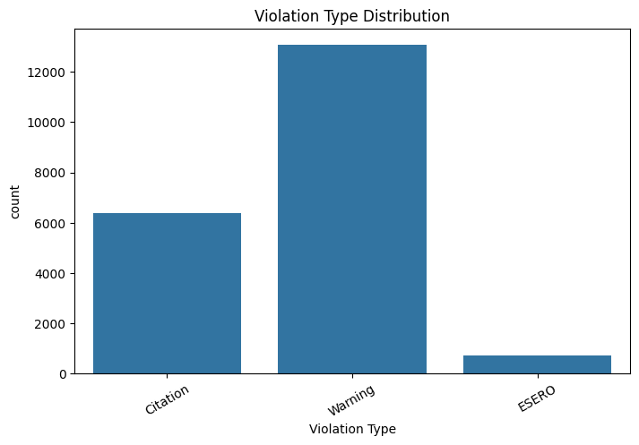

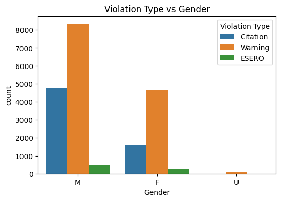

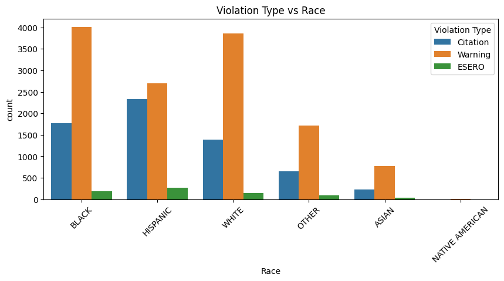

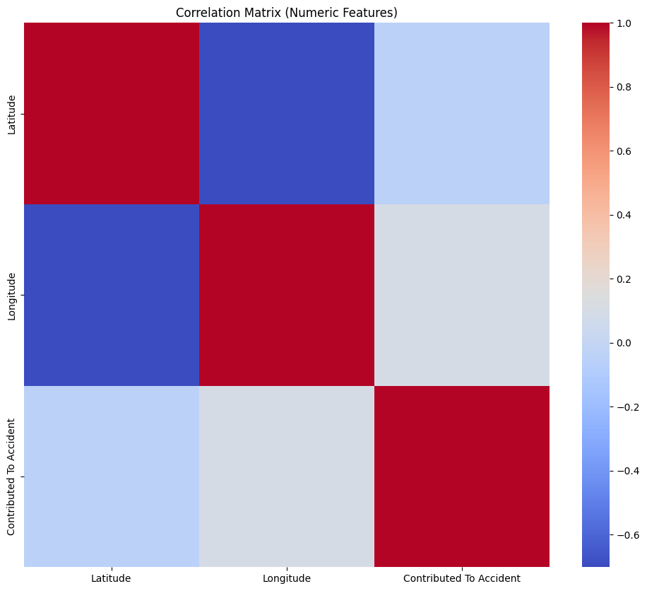

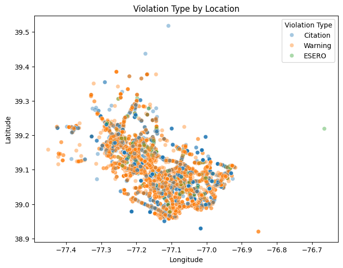

```python
import matplotlib.pyplot as plt
import seaborn as sns

# 1. Violation Type Distribution
plt.figure(figsize=(8,5))
sns.countplot(x='Violation Type', data=df)
plt.title("Violation Type Distribution")
plt.xticks(rotation=30)
plt.show()

# 2. Violation Type vs Gender
plt.figure(figsize=(6,4))
sns.countplot(x='Gender', hue='Violation Type', data=df)
plt.title("Violation Type vs Gender")
plt.show()

# 3. Race vs Violation Type
plt.figure(figsize=(10,4))
sns.countplot(x='Race', hue='Violation Type', data=df)
plt.title("Violation Type vs Race")
plt.xticks(rotation=45)
plt.show()

# 4. Correlation Matrix
plt.figure(figsize=(12,10))
sns.heatmap(df.select_dtypes(include=['int64', 'float64']).corr(), cmap='coolwarm', annot=False)
plt.title("Correlation Matrix (Numeric Features)")
plt.show()

# 5. Location Scatterplot
plt.figure(figsize=(8,6))
sns.scatterplot(x='Longitude', y='Latitude', hue='Violation Type', data=df, alpha=0.4)
plt.title("Violation Type by Location")
plt.show()
```

```python
df.to_csv("traffic_violations_cleaned.csv", index=False)
```

Check for missing values

```python
import pandas as pd

df = pd.read_csv("traffic_violations_cleaned.csv")

missing_counts = df.isnull().sum()

missing_columns = missing_counts[missing_counts > 0]

print("Missing values per column:")
print(missing_columns)
```

```
Missing values per column:
Series([], dtype: int64)
```

Defining the target

```python
from sklearn.preprocessing import LabelEncoder
import pandas as pd

# Load cleaned dataset
df = pd.read_csv("traffic_violations_cleaned.csv")

# Step 1: Define target and features
y = df["Violation Type"]
X = df.drop(columns=["Violation Type"])

# Step 2: Encode target
le = LabelEncoder()
y_encoded = le.fit_transform(y)

# Step 3: Identify categorical columns in X
categorical_cols = X.select_dtypes(include=['object']).columns.tolist()

# Step 4: One-hot encode features only
X_encoded = pd.get_dummies(X, columns=categorical_cols, drop_first=False)

# Step 5: Print shapes and preview
print("X shape:", X_encoded.shape)
print("y shape:", y_encoded.shape)
X_encoded.head()
```

```
X shape: (20150, 119)
y shape: (20150,)
```

|  | Latitude | Longitude | Accident | Belts | Personal Injury | Property Damage | Fatal | Commercial License | HAZMAT | Commercial Vehicle | ... | SearchReasonGroup_Behavior | SearchReasonGroup_Commercial | SearchReasonGroup_Equipment | SearchReasonGroup_License | SearchReasonGroup_Misc | SearchReasonGroup_NotApplicable | SearchReasonGroup_Other | SearchReasonGroup_Registration | SearchReasonGroup_Speeding | SearchReasonGroup_Traffic |
| --- | --- | --- | --- | --- | --- | --- | --- | --- | --- | --- | --- | --- | --- | --- | --- | --- | --- | --- | --- | --- | --- |
| 0 | 39.058970 | -76.997734 | False | False | False | False | False | False | False | False | ... | False | False | False | False | False | False | False | False | False | True |
| 1 | 39.058199 | -77.054977 | False | False | False | False | False | False | False | False | ... | False | False | False | False | False | True | False | False | False | False |
| 2 | 38.977576 | -77.100526 | False | False | False | False | False | False | False | False | ... | False | False | False | False | False | True | False | False | False | False |
| 3 | 38.993102 | -77.026927 | False | False | False | False | False | True | False | False | ... | False | False | False | True | False | False | False | False | False | False |
| 4 | 39.069426 | -77.162020 | False | False | False | False | False | False | False | False | ... | False | False | True | False | False | False | False | False | False | False |

5 rows × 119 columns